# まとめ

機械学習

川田恵介

# 機械学習の分類

## 研究計画

- あらゆる研究においては、明確なゴール設定が必須
- 不適切なゴール：「計量経済学 | 統計学 | 機械学習を使って、日本社会を明らかにする」
  - あまりにも不明確 | 野心的
- まだ不適切なゴール： 「 $Y =$ 賃金の決定構造を、 $X = \{$ 性別、年齢、居住地 $\}$ から明らかにする」
  - 依然として難しい
- 自身の使える分析道具と紐付けたゴール設定が現実的

## 機械学習の分類

- 様々な分析ツールを提供
- 大別すると
  - 教師付き学習: $\{Y,X\}$ が観察できるデータから、 $Y\sim X$ を推定
  - 教師無し学習: $Y$ が観察できないデータから、 $Y\sim X$ を推定
  - 他にも,強化学習など
- 例: Chat Bot GPT = 教師付き学習 $+$ 強化学習

## 教師無し学習: 例

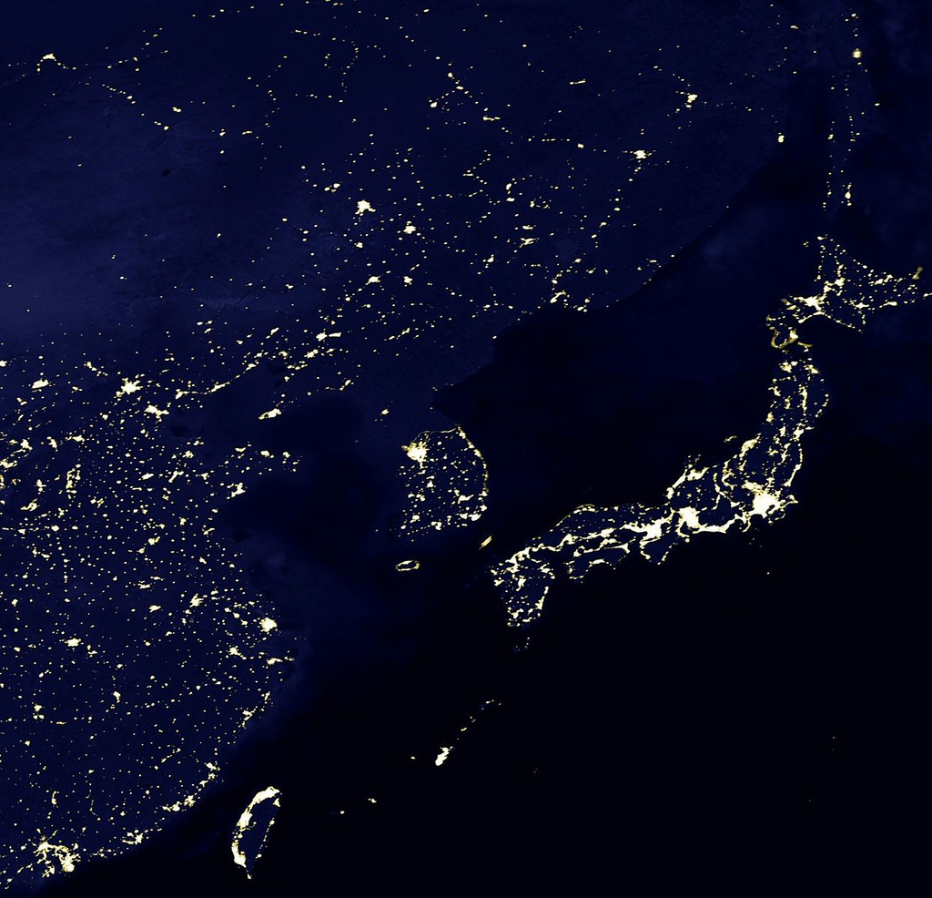

## 教師無し学習による都市圏の同定

- $X=$ 座標, $Y=$ 都市圏 (観察できない)
- アイディア: 光の塊 $=$ 都市圏?

## 教師無し学習: 問題点

- 幅広い状況に”自信を持って”応用するのは難しい?
  - どのように評価するのか？
  - 定式化に依存していないか?

# 教師付き学習の復習

## 教師付き学習 = 母平均の推定

- 教師付き学習 $:=$ 母集団の特徴を柔軟に推定するツール
- 典型的には、母平均関数 $E[Y|X]$ を”近似する”関数 $g(X)$ を推定
  - 伝統的な推定方法は、 $g(X)$ の”形状”をある程度決め内
  - 機械学習は、より多くをデータに決めされることができる

## ポイント: データへの適応

- $Y_i=E[Y|X]+$ 個人差
  - データ上のパターン $\{Y_i,X_i\}$ は、 $E[Y|X]$ について一定の情報をもつ
  - データに適合されることで、情報を引き出せる

## ポイント: 過剰適合

- $Y_i=E[Y|X]+$ 個人差
  - データに適合しすぎると、 個人差が $g(X)$ に反映され過ぎてしまう
  - データに偶然含まれた”ハズレ値”に致命的な影響を受けてしまう

## 工夫

- 複雑なモデルを適度に単純化する
  - 剪定
- 複雑なモデルの集計値を予測値とする
  - Bagging/RandomForest

# 応用: 予測研究

- $g(X)$ は、優れた予測モデルになりうる
- $\iff E[Y|X]$ をうまく近似できていたとしても、予測性能は保証しない
  - テストすべき

## 予測問題

- 新しい事例 $i$ について、 $Y_i\sim g(X_i)$ を達成する
- 予測誤差
- $$Y_i-g(X_i)=\underbrace{Y_i-E[Y_i|X_i]}_{予測不可能}+\underbrace{E[Y_i|X_i]-g(X_i)}_{予測可能}$$
- 予測可能な部分を0にできたとしても、予測不可能分が大きい可能性がある
  - 個人差が大きい社会データでは、特に深刻な恐れ

## 独立したデータによる評価

- 予測不可能分の大きさを”理論的”に予測することは不可能
- データを分割して評価する必要がある
  - 訓練データ: モデルの推定
  - テストデータ: モデルの評価

# 応用: 母集団の推論

- 母平均全体ではなく、母集団の”特定の特徴”であれば、より高い精度で推定できる
  - 区間として推定可能
  - $\iff$ 予測では困難

## 特徴

- 出発点は分布: 各 $\{Y,D,X\}$ 組み合わせについて、事例数(割合)
- 知りたい分布の特徴: $\theta$
  - 平均, 分散
  - 本講義では、 $\tau=E[Y|D+1,X]-E[Y|D=0,X]$

## 部分線形モデル

- $$E[Y|D,X]=\underbrace{\tau}_{知りたい特徴}\times D + f(X)$$
1. $$E[Y|X]\sim g_Y(X),E[D|X]\sim g_D(X)$$
   を機械学習で推定
2. $$Y-g_Y(X)\sim D-g_D(X)$$
   をOLSで推定
- 信頼区間が計算可能
- 効果の異質性推定へ拡張可能

# 注意点

- 母集団の理解に向けた、機械学習の単純な応用には注意が必要

## 単純化の弊害

- 機械学習で $E[Y|D,X]\sim g(D,X)$ を直接推定し、 $g(1,X)-g(0,X)$ を推定値とすればいいのでは?
- 例：世代間格差移転問題を機械学習により明らかにする
  - $Y = 子供世代の所得$ , $X = 父親の学歴, 母親の学歴$
- 父親の学歴のみを用いた決定木が推定された
  - 母親の学歴は関係ない？？？？

## 信頼区間計算の失敗

- 教師付き学習の**予測性能**は、データ分割で評価できる
- 母平均の特徴についての含意は限定的
  - (この範囲内のどこかにあります!!)とは言えない
- 信頼区間を計算すればいいのではないか
  - うまくいかない

## 数値例

- $E[Y|X]=0$

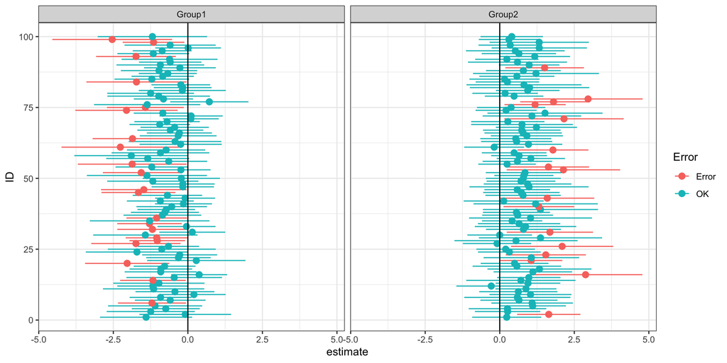

## なぜ

- 信頼区間の大前提は、
  $$Y_i=E[Y|X]+\underbrace{個人差}_{平均=0}$$
- 機械学習で生成されるモデルは一般に、 個人差も反映している
  - 決定木: 高い値を予測されたグループにおいて、個人差も高め
- 誤った信頼区間が計算されがち

## Honest Tree

- サンプル分割を用いて解決
  - 訓練データ: サブグループを形成
  - テストデータ: 信頼区間を計算

## 数値例

- $E[Y|X]=0$

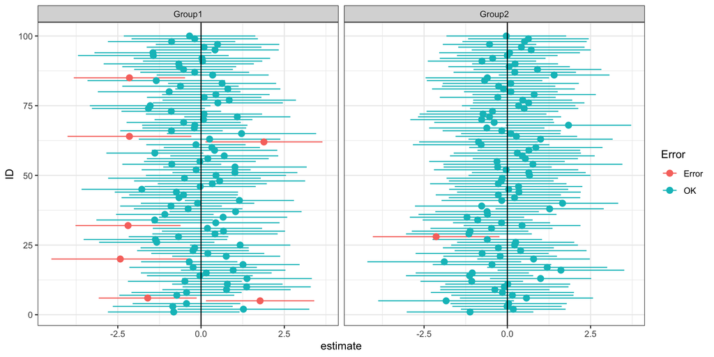

## まとめ

- 機械学習をさまざまな局面で有益
- ただし、安直な応用は極めて危険